# CPS85 Lab

Sep. 8, 2015

## PLOT 1

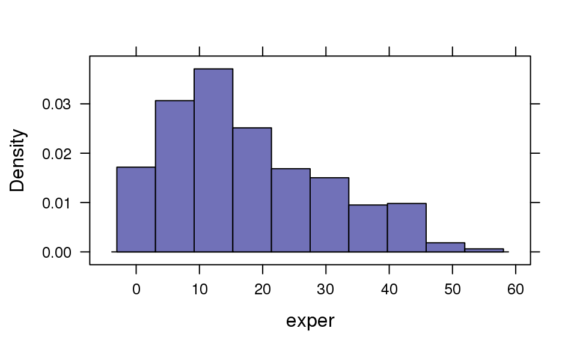

```r
histogram(~exper, data=CPS85)
```

```r
favstats(~exper, data=CPS85)
```

```
##  min Q1 median Q3 max    mean       sd   n missing
##    0  8     15 26  55 17.8221 12.37971 534       0
```

The histogram of density of population versus work experience in years is strongly right skewed. The data show that work experience in years has a mean of 17.822 years, and a median of 15 years; the data has a standard deviation of 12.3797 and ranges from 0 to 55. The sample size is 534. people.

## PLOT 2

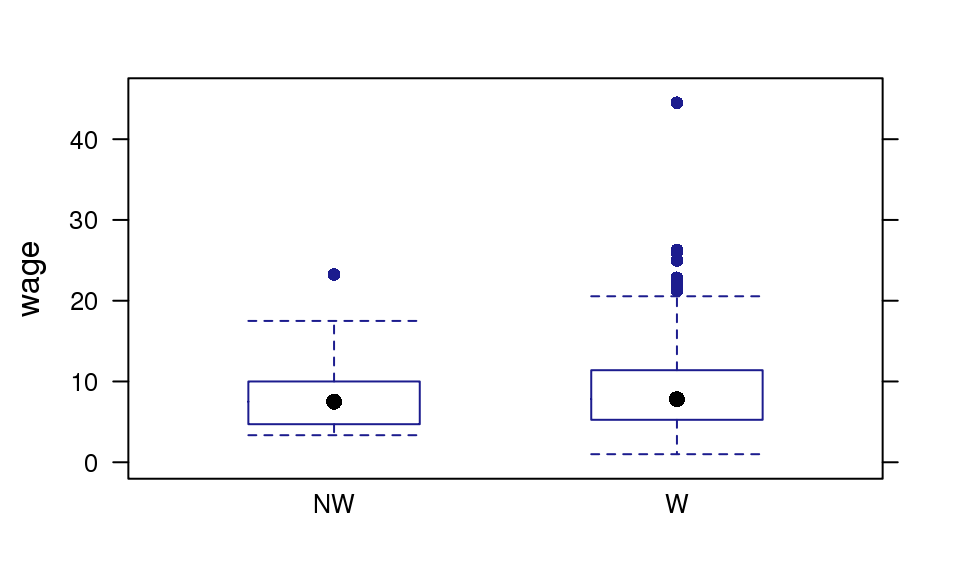

```r
bwplot(wage ~ race, data=CPS85)
```

```r
favstats(wage ~ race, data=CPS85)
```

```
##   race  min    Q1 median     Q3   max     mean       sd   n missing
## 1   NW 3.35 4.710   7.50 10.000 23.25 8.058358 4.078379  67       0
## 2    W 1.00 5.255   7.81 11.395 44.50 9.162612 5.262928 467       0
```

## PLOT 3

```r
favstats(exper ~ race, data=CPS85)
```

```
##   race min Q1 median   Q3 max     mean       sd   n missing
## 1   NW   0  8     17 28.5  43 18.79104 12.22087  67       0
## 2    W   0  8     15 25.5  55 17.68308 12.40908 467       0
```

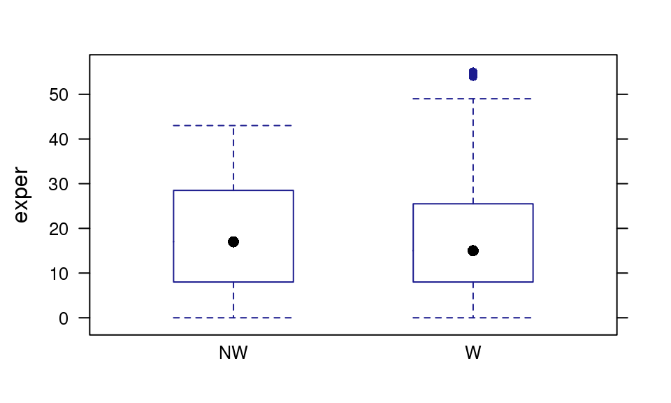

```r
bwplot(exper ~ race, data=CPS85)
```

Data for work experience for nonwhites has a median of 17 years, whereas data for work experience for whites has a median of 15 years. The range for whites’ work experience is slightly greater than that of nonwhites’ work experience. The maximum work experience for whites at 55 years is larger than the maximum work experience for nonwhites at 43 years.